# Lab 1: Review of Probability

Author

Dr. Irene Vrbik

## Introduction

This lab is intended to recap some basic probability terms and concepts. See the Resources section for some recommended textbooks to learn more.

## Sample Spaces

As defined in [Freund](https://go.exlibris.link/NBZm3HmC), 2014: a **sample space** is the set of all possible outcomes of an experiment. It is usually denoted by the letter $S$ or Greek letter $\Omega$. Each outcome in a sample space is called an *element* of the sample space.

If a sample space has a *finite* number of elements, we may list the elements in the usual set notation. For example, we can construct a sample space for the experiment that consists of tossing a single coin as follows:

$$S = \{\text H, \text T\}$$
where H and T stand for head and tail, respectively. We could construct a sample space for the experiment that consists of tossing a single coin until a head appears:
$$S = \{\text{H, TH, TTH, TTTH, TTTTH,} \dots \}$$
This *infinite* sample space is said to be *countable* since the number of elements can be matched one-to-one with the whole numbers.

## Discrete Random Variables

In some scenarios, e.g., rolling a die, the events correspond to numbers. When that is not the case, we can map the outcomes of these specific experiments, to numbers on the real line. A **random variable** is a function that maps the outcome of a experiment to a real number.

For example, we can map the experiments involving flipping a coin using random variable $X$ which counts the total number of heads (H). If we are only flipping the coin once our sample space $S = \{H,T\}$ would map to:
$$\begin{align}
X(H) = 1 && X(T) = 0
\end{align}$$
If we are flipping the coin twice, our sample space $S = \{HH, HT, TT, TH\}$ would map to:
$$\begin{align}
X(HH) = 2 && X(HT) = 1\\
X(TT) = 0 && X(TH) = 1
\end{align}$$

While $X$ is a function, we typically drop the parenthesis and denoted random variables by capital letters from the end of the alphabet, (such as $X$, $Y$, $Z$).

The *realization* of a random variable is the result of applying the random variable (i.e., function) to an observed outcome of a random experiment. The realization of a random variable is typically denoted using the corresponding lowercase letters, e.g., $x$ is a realization of $X$.

The **domain** of a random variable is the sample space $S$. This set of real values obtained from the output of the random variable is called its **range**. A random variable is **discrete** if its domain consists of a finite (or countably infinite) set of values. A random variable is continuous if its domain is uncountably infinite.

## Probability

We can express probability statements both in terms of events and random variables. For instance, we if we are flipping a single coin and define a random variable $X$ to count the number of H’s, we can compute:
$$\begin{align}
P(X = 0) &= P(T) = 0.5\\
P(X = 1) &= P(H) = 0.5
\end{align}$$
If we flip that coin twice, we calculate the probability of $X$ taking the values 0, 1 and 2 as follows:
$$\begin{align}
P(X = 0) &= P(TT) = \frac{1}{4}\\
P(X = 1) &= P(HT \cup TH) = \frac{2}{4} = \frac{1}{2} = 0.5 \\
P(X = 2) &= P(HH) = \frac{1}{4}\\
\end{align}$$

In reference to the experiment in which two dice are tossed, we could define a random variable $Y$ that maps the sample space to the sum of the two dice. In this case, the sample space
$$\begin{align}
S =
\begin{cases}
(1,1), (1,2), (1,3), (1,4), (1,5), (1,6),\\
(2,1), (2,2), (2,3), (2,4), (2,5), (2,6),\\
(3,1), (3,2), (3,3), (3,4), (3,5), (3,6),\\
(4,1), (4,2), (4,3), (4,4), (4,5), (4,6),\\
(5,1), (5,2), (5,3), (5,4), (5,5), (5,6),\\
(6,1), (6,2), (6,3), (6,4), (6,5), (6,6)
\end{cases}
\end{align}$$
maps to
$$\begin{align}
Y(S) =
\begin{cases}
2,& 3,& 4,& 5,& 6,& 7,\\
3,& 4,& 5,& 6,& 7,& 8,\\
4,& 5,& 6,& 7,& 8,& 9,\\
5,& 6,& 7,& 8,& 9,& 10, \\
6,& 7,& 8,& 9,& 10,& 11, \\
7,& 8,& 9,& 10,& 11,& 12 \\
\end{cases}
\end{align}$$

## Probability Mass Functions

If $X$ is a discrete random variable, the function given by $f(x) = P(X= x)$ for each $x$ within the range of $X$ is called the **probability mass function** or PMF of $X$.

Based on the axioms of probability discussed in lecture, a function can serve as the probability distribution of a discrete random variable $X$ if and only if its values, $f(x)$, satisfy the following conditions:

1. $f(x) \geq 0$ for each value within its domain
2. $\sum_x f(x) = 1$, where the summation extends over all the values within its domain.

> N.B. In DATA 582, I will commonly use $p(x)$ instead of $f(x)$ to represent PMF/PDFs

In other words, the PMF of a random variable provides the probability of occurrence of every value in the range of the random variable. A PMF is usually represented by

1. a table
2. a bar chart
3. a function

For example, the PMF for $Y$, the sum of two dice, can be displayed as a table:

| x | 2 | 3 | 4 | 5 | 6 | 7 | 8 | 9 | 10 | 11 | 12 |
| --- | --- | --- | --- | --- | --- | --- | --- | --- | --- | --- | --- |
| P(X = x) | 1/36 | 2/36 | 3/36 | 4/36 | 5/36 | 6/36 | 5/36 | 4/36 | 3/36 | 2/36 | 1/36 |

a bar chart:

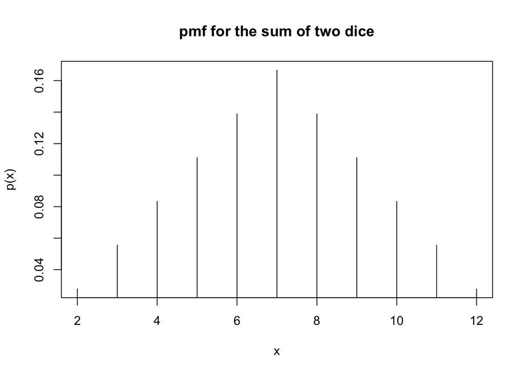

```r
x = 2:12
p.x <- c(1:6, 5:1)/36
plot(x, p.x, type = 'h', xlab = 'x',
     ylab = 'p(x)', main = 'pmf for the sum of two dice')
```

or a function:
$$\begin{align}
f(x) &= \frac{6 - |x - 7|}{36} & \text{for }x = 2, 3, \dots, 12
\end{align}$$
You can verify that substituting any value in the permitted range will agree with the table and graph above. Note that it is very important to specify the range of the function ($x = 2,3, \dots, 12$) since substituting values of $x = 0, 14$, for example, would produce that nonsensical probability of -1/36.

## Probability Density Function

If $X$ is a continuous random variable, a function with values $f(x)$, defined over the set of all real numbers, is called a **probability density function**, or PDF, of the continuous random variable $X$ if and only if
$$\begin{align}
P(a \leq X \leq b) = \int_a^b f(x) dx
\end{align}$$
for any real constants $z$ and $b$ with $a \leq b$.

> Note that $f(c)$, the value of the pdf of $X$ at $c$, does **NOT** give the $P(X=c)$ as in the discrete case.

A function can serve as a probability density of a continuous random variable $X$ if its values, $f(x)$, satisfy the conditions

1. $f(x) \geq 0$ for $-\infty < x < \infty$
2. $\int_{-\infty}^{\infty} f(x) dx = 1$

## Exercises

1. Construct the sample space for flipping a coin three times.

   **Solution (click to view)**

   $S = \{TTT, TTH, THT, THH, HTT, HTH, HHT, HHH\}$
2. Suppose we define a random variable $X$ that counts the number of Tails in the experiment from the previous question. What is the range of this random variable.

   **Solution (click to view)**

   range = $0,1,2,3$
3. Two socks are selected at random and removed in succession from a drawer containing give brown socks and three green socks. List the elements of the sample space, the corresponding probabilities, and the corresponding values $w$ of the random variable $W$, where $W$ is the number of brown socks selected.

   **Solution (click to view)**

   Let B represent the event of putting a brown socks and G represent the event of pulling a green socks. The sample space, range, and probabilities are shown in the following table:

   ```r
   S = c("BB", "BG", "GB", "GG")
   Probability = c("5/14", "15/56", "15/56", "3/28")
   w = c(2,1,1,0)

   sol = cbind(S, Probability, w)
   kable(sol)
   ```

   | S | Probability | w |
   | --- | --- | --- |
   | BB | 5/14 | 2 |
   | BG | 15/56 | 1 |
   | GB | 15/56 | 1 |
   | GG | 3/28 | 0 |

4. The PDF of continuous random variable $X$ is given by

   $$\begin{align}f(x) = \begin{cases}\frac{1}{5} & \text{for } 2 < x< 7\\0 & \text{elsewhere}\end{cases}\end{align}$$

   Draw its graph and verify that the total area under the curve is equal to 1.

   **Solution (click to view)**

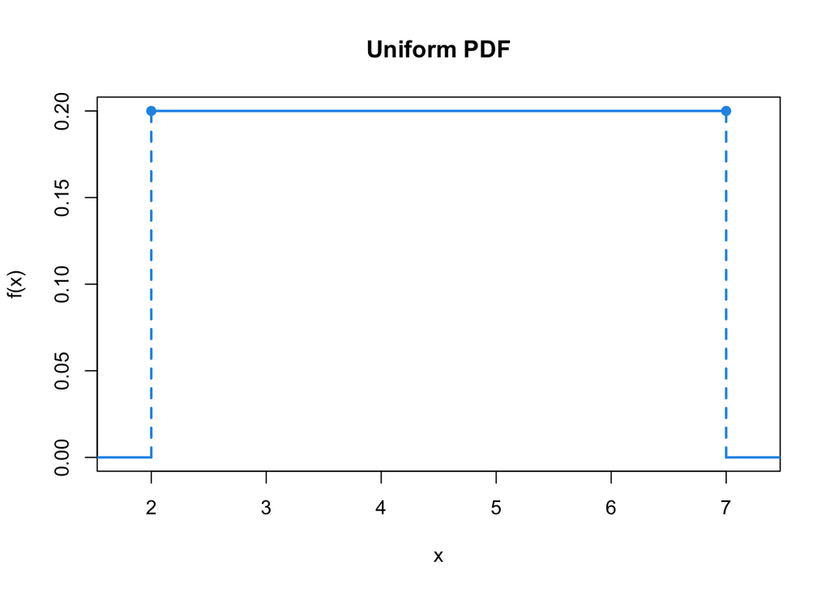

5. Find $P(3 < X < 5)$

   **Solution (click to view)**

   $$\begin{align}P(3 < X < 5) &= \int_3^5 1/5 dx = \frac{x}{5} \biggr\rvert_3^5 = \frac{5}{5} - \frac{3}{5} = \frac{2}{5} = 0.4\end{align}$$
6. A local business ships their product either using Canada Post or Purolator. Historical this company has found that Canada Post ships their packages by the expected delivery date 86% of the time, whereas Purolator delivers by the expected delivery date 93% of the time. This business uses Purolator twice as often as Canada Post. Use this information to answer the following questions. Hint: you may find it useful to draw a tree diagram to represent this information.
   1. What is the probability that a randomly selected package from this company was delivered by Purolator? (you may assume that Canada Post and Purolator are the only shipping companies this company uses).

      **Solution (click to view)**

      Let A be the event that a randomly selected package from this company was delivered by Canada Post, and B be the event that a randomly selected package from this company was delivered by the expected delivery date.

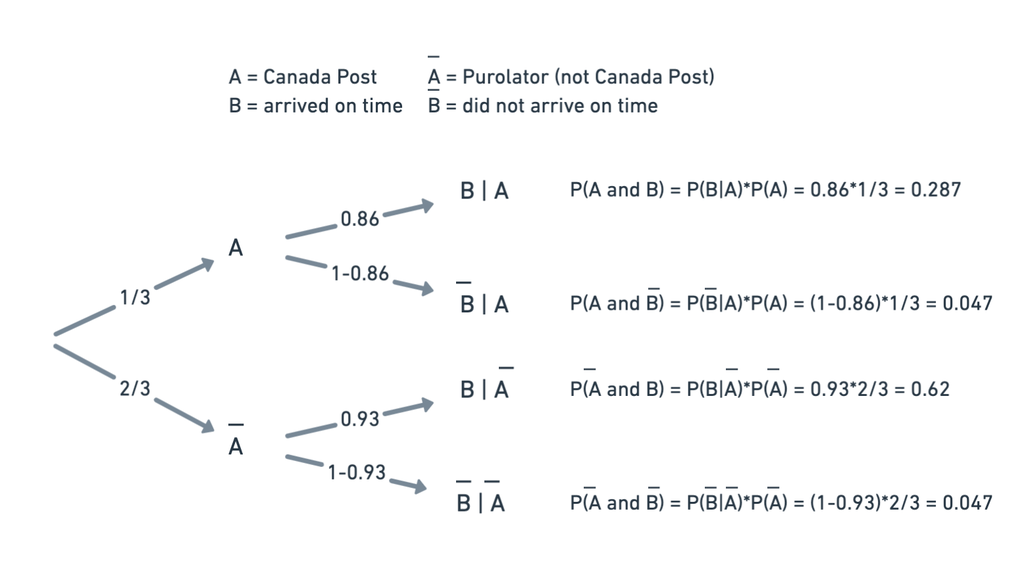

      $$\begin{align}P(A) + P(\overline{A})&= 1\\x + 2x &= 1 & \text{since Purolator is used twice as often}\\\rightarrow x = P(A) &= 1/3 \\\rightarrowP(\overline{A}) &= 2/3 \end{align}$$
   2. What is the probability that a randomly selected package from this company was delivered on time by Canada Post?

      **Solution (click to view)**

      $$\begin{align*}
      P(A \cap B) &= P(B \mid A)P(A)\\
      &= 0.86 \times 0.3333333\\
      &= 0.2866667 \approx 0.287 \\
      \end{align*}$$
   3. What is the probability that a randomly selected package from this company was not delivered by the expected delivery date?

      **Solution (click to view)**

      $$\begin{align*}
      P(\overline B) &=
      P(\overline B \mid A)P(A) +
      P(\overline B \mid \overline A)P(\overline A) & \text{partition thrm}\\
      &= (0.14)(0.3333333) + (0.07)(0.6666667) \\
      &= 0.0466667 + 0.0466667 \\
      &= 0.0466667 + 0.0466667 \\
      & \approx 0.093
      \end{align*}$$
   4. Suppose a package from this company was not delivered by the expected delivery date. What is the probability that it was delivered by Canada Post?

      **Solution (click to view)**

      $$\begin{align*}
      P(A \mid \overline B)
      &= \frac{P(\overline B \mid A)P(A)}{\sum_i P(\overline B\mid A_i)P(A_i)} & \text{Bayes Thrm }\\
      &= \frac{(0.14)(0.3333333}{(0.14)(0.3333333) + (0.07)(0.6666667)} \\
      &= \frac{(0.0466667)}{(0.0466667) + (0.0466667)} \\
      &= 0.5 \approx
      0.5\\
      \end{align*}$$
7. Consider the following contingency table which summarize three months of emails for an email account. The emails were either spam (`spam = 1`) or not spam (`spam = 0`). `format = 1` indicates that the email was written using HTML (e.g. may have included bolding or active links), otherwise `format = 0`

   ```
           format
   spam     text HTML Total:
     0       490 1287   1777
     1       101   83    184
     Total:  591 1370   1961
   ```

   1. Suppose that an email is randomly selected from the sample emails use in this question, and define events A = `{spam = 1}` and B = `{format = 1}`. Calculate $\Pr(A)$.

      **Solution (click to view)**

      $$\begin{align}
      \Pr(A) &= \frac{\text{total number of spam emails}}{\text{total number of emails}} = \frac{184}{1961} = 0.094
      \end{align}$$
   2. Calculate $\Pr(A\cap B)$.

      **Solution (click to view)**

      $$\begin{align}
      \Pr(A\cap B) &= \frac{\text{number of spam emails written using HTML}}{\text{total number of emails}} \\
      & = \frac{83}{1961} = 0.042
      \end{align}$$
   3. Write down $\Pr(A\cap B)$ in words

      **Solution (click to view)**

      **Solution (click to view)**

      **Solution (click to view)**

      $\Pr(B \mid A)$ represents the probability that a spam email is written using HTML
8. The following table gives the distribution of blood types in Canada. For example, 36% of the population has type A blood and a positive Rh factor.

   ```
                  A     B    AB    O
   Rh positive 0.36 0.076 0.025 0.39
   Rh negative 0.06 0.014 0.005 0.07
   ```

   A person with type O blood and a negative Rh factor can donate blood to any blood type. We define the following events:
   - A: The person has blood type A
   - B: The person has blood type B
   - C: The person has blood type AB
   - O: The person has blood type O
   - E: The person is Rh positive
   - F: The person is Rh negative
   1. Are A and 0 mutually exclusive?

      **Solution (click to view)**

      Yes since it is impossible for a person to have both bloodtypes
   2. Are events A and E are mutually exclusive?

      **Solution (click to view)**

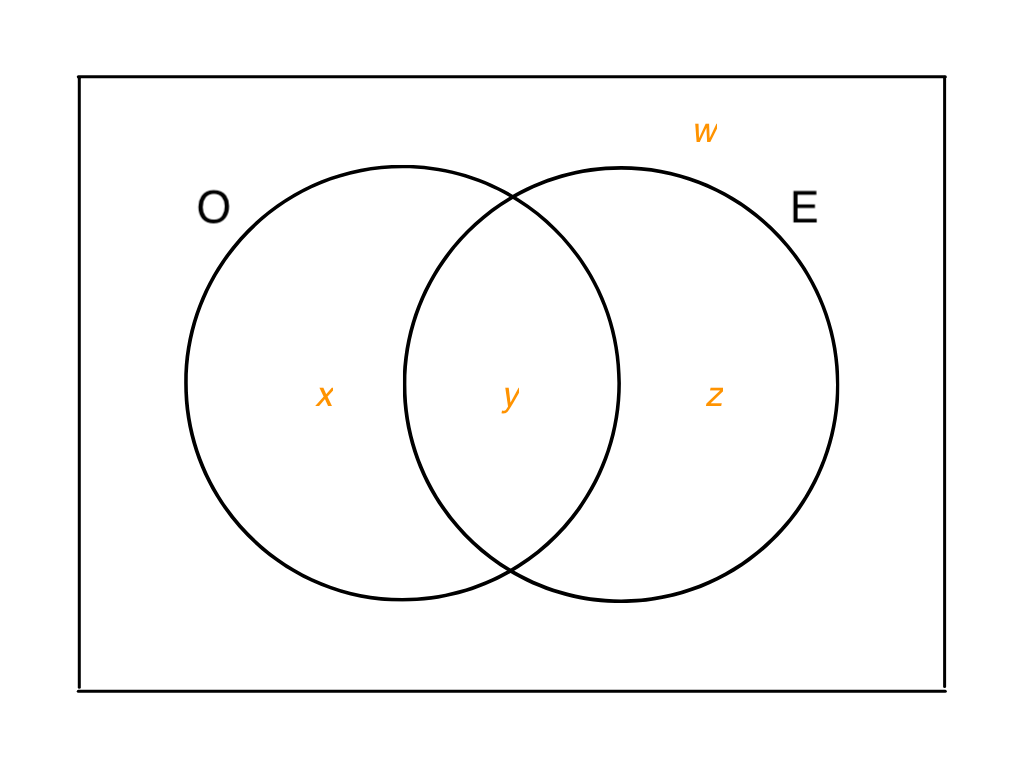

      **Solution (click to view)**

      $$\begin{align*}\text{in words: }& w \text{ corresponds to people with A, B, or AB blood type and Rh - }\\w &= P(\overline{O \cup E}) = P({\overline O \cap \overline E}) = 0.06 + 0.014 + 0.005 = 0.079\\ \text{in words: }& x \text{ corresponds to people with blood type 0 and Rh - }\\x &= P(O \cap \overline{E}) = 0.07\\ \text{in words: }& y \text{ corresponds to people with blood type 0 and Rh + }\\y &= P(O \cap {E}) = 0.39\\ \text{in words: }& z \text{ corresponds to people with blood type A, B, or AB and Rh + }\\z &= P(\overline O \cap {E}) = 0.36 + 0.076+0.025= 0.461\\ \end{align*}$$
   5. Calculate $\Pr(O)$

      **Solution (click to view)**

      $$\begin{align*}
      P(O)& = x + y = 0.39+0.07 = 0.46
      \end{align*}$$
   6. Given that a randomly selected person has type O what is the probabilty that they can donate blood to any person with any blood type?

      **Solution (click to view)**

      $$\begin{align*} P(F \mid D) &= P(F\cap D)/P(D) \\ & =0.07/(0.39+0.07) \approx 0.152 \end{align*}$$

## Resources

- Introduction to Probability 2nd ed. Athena Scientific, 2008. ISBN: 978188652923 *by Bertsekas, Dimitri, and John Tsitsiklis.*
- [John E. Freund’s mathematical statistics with applications](https://go.exlibris.link/NBZm3HmC) 2014, 8th ed, *by Miller, Irwin; Miller, Marylees; Freund, John E*
- [Introduction to mathematical statistics](https://go.exlibris.link/hphQsvym) 2005, 6th ed *by Hogg, Robert V; McKean, Joseph W; Craig, Allen T*
- [Miller & Freund’s Probability and Statistics for Engineers](https://go.exlibris.link/zB5msqn8), 2011, 8th ed. *by Johnson, Richard A; Miller, Irwin; Freund, John E*
- [A course in Probability](https://www.google.ca/books/edition/A_Course_in_Probability/Be9fJwAACAAJ?hl=en) 2006 *by Neil A. Weiss*
- The [OpenIntro Statistics](https://www.openintro.org/book/os/) textbook *by Mine Cetinkaya-Rundel and Christopher D Barr*. (this textbook does not contain any calculus)